# Model

Huaying Qiu

2025-03-29

# Introduction

This Rmd servers to fit models using PDAC data, mainly neutrophil features, to predict patient/FOV status.

# Library

```r
library(tidyverse)
library(caret)
library(glmnet)
library(randomForest)
library(ggcorrplot)
library(scatterPlotMatrix)
library(reshape2)
set.seed(123)
```

# Load data

```r
data <- read_csv("~/pdac/data/All_anno_clean_metadata_Tumor distance-inf_0328.csv")
```

## Summary

```r
summary(data)
```

```
##      cellID          PointNum         fov              cellLabel
##  Min.   :     1   Min.   : 1.00   Length:854287      Min.   :    1
##  1st Qu.:214518   1st Qu.: 9.00   Class :character   1st Qu.: 5477
##  Median :428089   Median :20.00   Mode  :character   Median :11014
##  Mean   :427981   Mean   :19.38                      Mean   :12048
##  3rd Qu.:641660   3rd Qu.:29.00                      3rd Qu.:17376
##  Max.   :855232   Max.   :39.00                      Max.   :40519
##
##      Y_cent              X_cent         cell_size      cell_cluster
##  Min.   :   0.4167   Min.   :   0.4   Min.   :   2.0   Length:854287
##  1st Qu.: 711.6144   1st Qu.: 683.0   1st Qu.:  77.0   Class :character
##  Median :1319.8790   Median :1305.8   Median : 118.0   Mode  :character
##  Mean   :1331.8741   Mean   :1296.7   Mean   : 133.5
##  3rd Qu.:1920.7330   3rd Qu.:1889.2   3rd Qu.: 172.0
##  Max.   :2873.8980   Max.   :2718.6   Max.   :5073.0
##
##    Podoplanin        CD45.RA             CD1c              MPO
##  Min.   :0.0000   Min.   :0.00000   Min.   :0.00000   Min.   :0.00000
##  1st Qu.:0.0000   1st Qu.:0.00000   1st Qu.:0.00000   1st Qu.:0.02019
##  Median :0.0000   Median :0.00000   Median :0.00343   Median :0.03411
##  Mean   :0.0479   Mean   :0.05085   Mean   :0.11725   Mean   :0.08667
##  3rd Qu.:0.0000   3rd Qu.:0.02046   3rd Qu.:0.15317   3rd Qu.:0.06254
##  Max.   :1.0000   Max.   :1.00000   Max.   :1.00000   Max.   :1.00000
##
##      CD169              HLA.DR            GATA3             CXCR5
##  Min.   :0.000000   Min.   :0.00000   Min.   :0.00000   Min.   :0.00000
##  1st Qu.:0.002343   1st Qu.:0.00000   1st Qu.:0.02473   1st Qu.:0.09274
##  Median :0.063164   Median :0.01115   Median :0.06127   Median :0.18777
##  Mean   :0.118519   Mean   :0.08541   Mean   :0.09544   Mean   :0.22615
##  3rd Qu.:0.164077   3rd Qu.:0.08518   3rd Qu.:0.10778   3rd Qu.:0.30729
##  Max.   :1.000000   Max.   :1.00000   Max.   :1.00000   Max.   :1.00000
##
##       CD15                Fe               CD45             CD11b
##  Min.   :0.000000   Min.   :0.00000   Min.   :0.00000   Min.   :0.00000
##  1st Qu.:0.000000   1st Qu.:0.00000   1st Qu.:0.00000   1st Qu.:0.01988
##  Median :0.000000   Median :0.01228   Median :0.00000   Median :0.04470
##  Mean   :0.054128   Mean   :0.06914   Mean   :0.08682   Mean   :0.11417
##  3rd Qu.:0.004252   3rd Qu.:0.06395   3rd Qu.:0.08604   3rd Qu.:0.11508
##  Max.   :1.000000   Max.   :1.00000   Max.   :1.00000   Max.   :1.00000
##
```

[output cut: 89 more lines]

```
##  Length:854287      Min.   :-112.69   Min.   :-113     Min.   :-88.04
##  Class :character   1st Qu.:  48.38   1st Qu.:  48     1st Qu.: 37.80
##  Mode  :character   Median : 339.79   Median : 339     Median :265.46
##                     Mean   :    Inf   Mean   : Inf     Mean   :   Inf
##                     3rd Qu.:1148.03   3rd Qu.:1148     3rd Qu.:896.90
##                     Max.   :    Inf   Max.   : Inf     Max.   :   Inf
##
##  distance_um_rounded
##  Min.   :-89
##  1st Qu.: 37
##  Median :265
##  Mean   :Inf
##  3rd Qu.:896
##  Max.   :Inf
##
```

## Subset data

Previous EDA has determined that neutrophil seemed to have the largest difference between the relapse and non-relapse groups. Therefore, here we subset the data to only neutrophil.

```r
data_neutrophil <- data %>%
  filter(cell_cluster == 'Neutrophil')
```

# Feature engineering

With the goal to predict relapse status at FOV/patient level and to utilize the variation of the single cell information to the fullest extend, we will engineer features using the following strategies and compare their performance:

1. Fit model on single cell level to predict each cell’s relapse/non-relapse status then give the FOV level prediction by majority-vote principle.
2. Create FOV-level features that captures the distribution of each marker such as mean, variance, quantiles, etc. However, since we only have 31 data points, we will likely just use the mean to prevent $p > n$ issue.
3. Using PCA to create a lower-dimensional representation of the features and use the mean PC of each FOV to build model.

In addition, we will split neutrophil into two categories — “near tumor” and “far from tumor”. The above mentioned metrics should be calculated within each group.

Let’s first define what’s “near tumor” and “far from tumor”:

- near tumor: $d\left(N,T\right) \leq 25 \mu m$.
- far from tumor: $d\left(N,T\right) \in \left(25, 100\right]\mu m$

Note that neutrophils that are either more than $100\mu m$ away from the tumor zone or within the tumor zone, i.e., $d\left(N,T\right) < 0$, will not be considered.

```r
data_filtered <- data_neutrophil %>%
  filter(distance_um <= 100 & distance_um > 0) %>%
  mutate(neu_cat = ifelse(distance_um <= 25, 'near', 'far'))
```

## Strategy 2

```r
functional_markers <- c("CD16", "MPO", "CD45.RA", "CD45RO", "HLA.DR", "Ki.67", "PD.1", "PD.L1")

fov_summary <- data_filtered %>%
  select(fov, all_of(functional_markers), Relapse, neu_cat) %>%
  group_by(fov, Relapse, neu_cat) %>%
  summarise(
    # Mean for each marker
    across(all_of(functional_markers), mean, .names = "{.col}_mean"),

    # # Median for each marker
    # across(all_of(functional_markers), median, .names = "{.col}_median"),
    #
    # # Standard deviation for each marker
    # across(all_of(functional_markers), sd, .names = "{.col}_std"),
    #
    # # 25th percentile
    # across(all_of(functional_markers), ~quantile(.,0.25), .names = "{.col}_q25"),
    #
    # # 75th percentile
    # across(all_of(functional_markers), ~quantile(., 0.75), .names = "{.col}_q75"),

    # cell count per fov
    neutrophil_count = n(),

    .groups = "drop"
  )

fov_summary <- fov_summary %>%
  pivot_wider(names_from = neu_cat,
              values_from = colnames(fov_summary)[4:12])
```

[interactive chart not shown]

## Strategy 3

```r
pca_matrix_near <- data_filtered %>%
  filter(neu_cat == 'near') %>%
  select(all_of(functional_markers)) %>%
  as.matrix()

pca_matrix_far <- data_filtered %>%
  filter(neu_cat == 'far') %>%
  select(all_of(functional_markers)) %>%
  as.matrix()
```

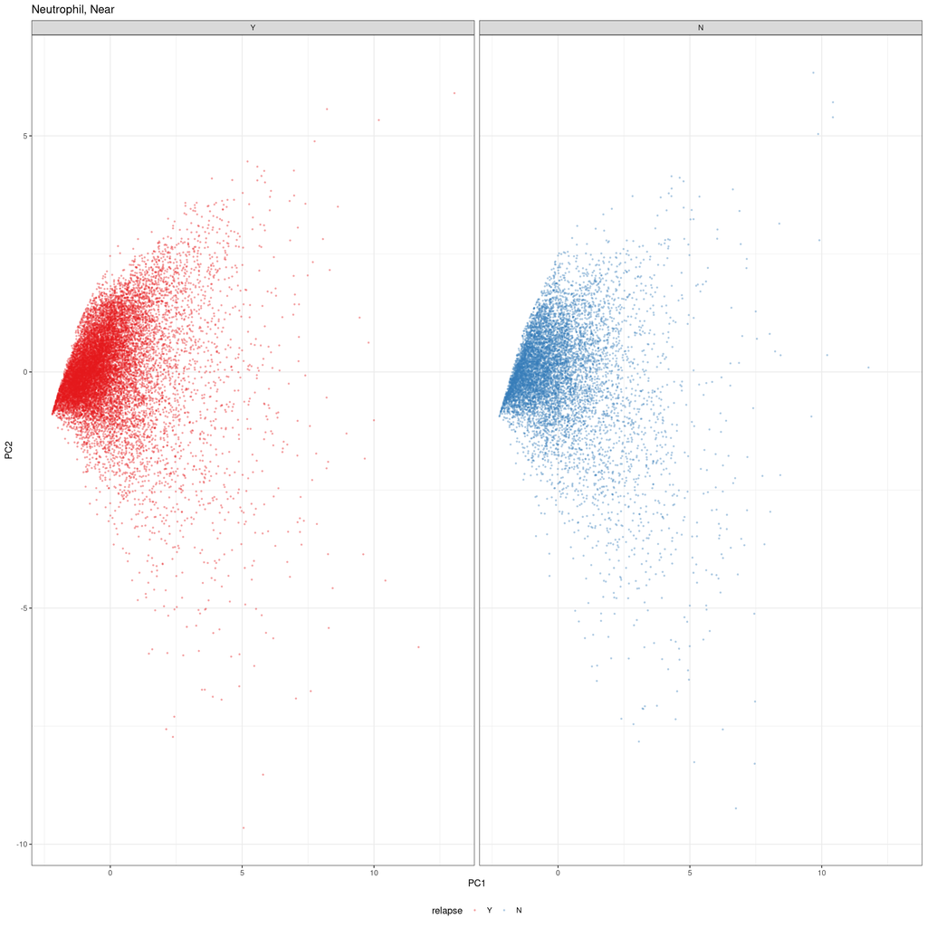

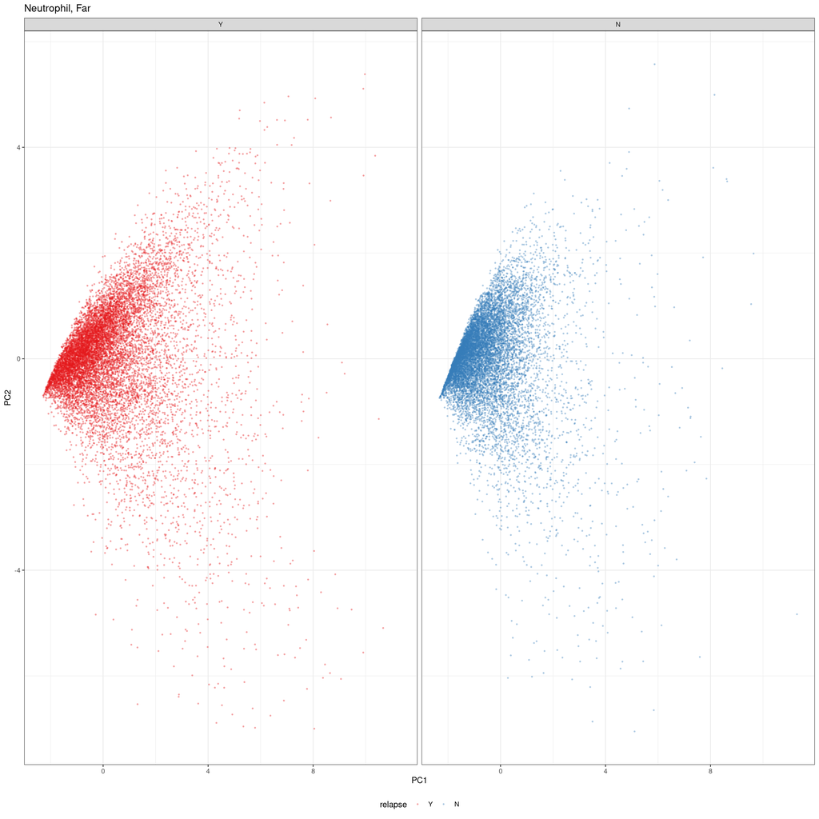

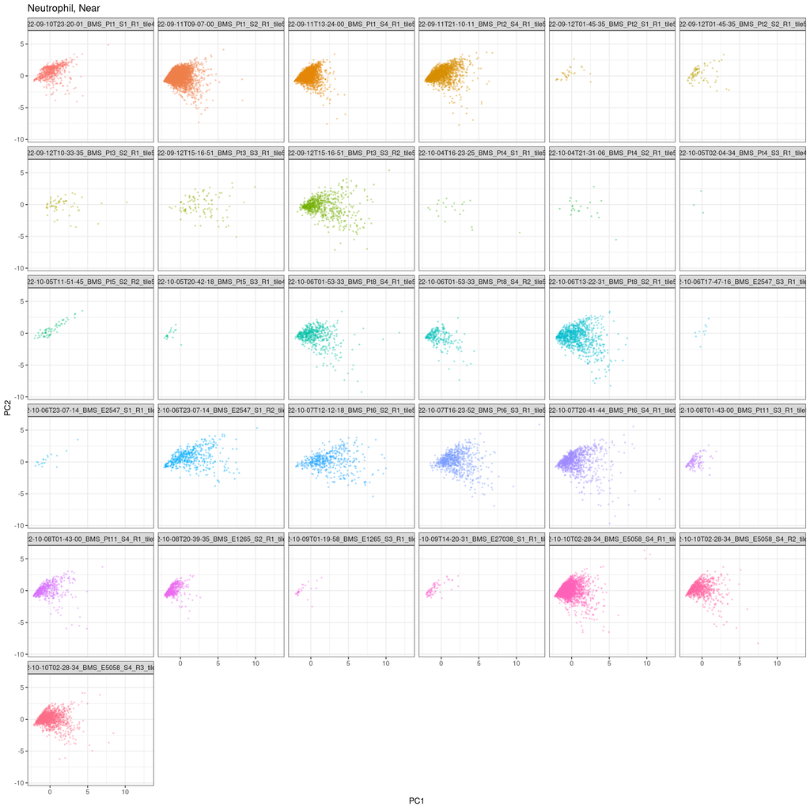

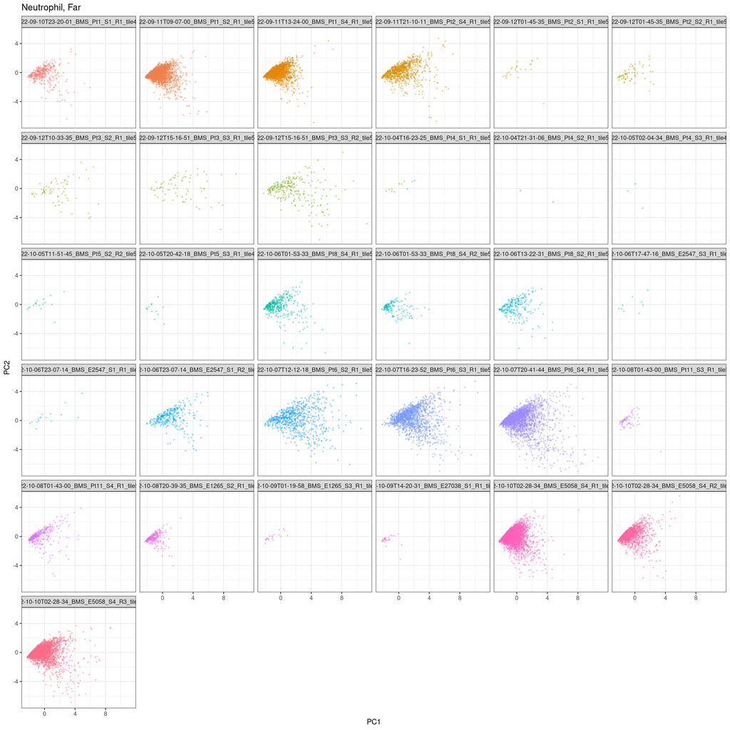

# Model Fitting

We will try these models:

- Random forest
- Logistic regression with elastic net

## Random forest

### Strategy 1

Since this leverage on the original single cell information and we will use the majority-vote pricinple to assign a final label at the aggregated level, we will try both patient level prediction and fov level prediction.

#### FOV level

```r
set.seed(123)

unique_fov <- unique(data_filtered$fov)

train_fov <- sample(unique_fov, round(0.7 * length(unique_fov)))

test_fov <- setdiff(unique_fov, train_fov)

train <- data_filtered %>%
  filter(fov %in% train_fov) %>%
  select(fov, Relapse, all_of(functional_markers), Age, Sex, BMI, Smoking_History, neu_cat) %>%
  mutate(Relapse = factor(Relapse),
         Sex = factor(Sex),
         Smoking_History = factor(Smoking_History),
         neu_cat = factor(neu_cat))

test <- data_filtered %>%
  anti_join(train) %>%
  select(fov, Relapse, all_of(functional_markers), Age, Sex, BMI, Smoking_History, neu_cat) %>%
  mutate(Relapse = factor(Relapse),
         Sex = factor(Sex),
         Smoking_History = factor(Smoking_History),
         neu_cat = factor(neu_cat))
```

```r
# m1 <- randomForest(Relapse ~ Age + Sex + BMI + Smoking_History + CD16 + MPO + CD45.RA + CD45RO + HLA.DR + Ki.67 + PD.1 + PD.L1, data = train)

m1 <- randomForest(Relapse ~ CD16 + MPO + CD45.RA + CD45RO + HLA.DR + Ki.67 + PD.1 + PD.L1 + neu_cat, data = train)

test$pred <- predict(m1, test)

test_agg <- test %>%
  group_by(fov, Relapse, pred) %>%
  count() %>%
  slice_max(order_by = n, n = 1) %>%
  ungroup() %>%
  select(-n)

cat("Accuracy:\n")
```

```
## Accuracy:
```

```r
sum(test_agg$Relapse == test_agg$pred) / nrow(test_agg)
```

```
## [1] 0.5
```

```r
cat("Variable importance: \n")
```

```
## Variable importance:
```

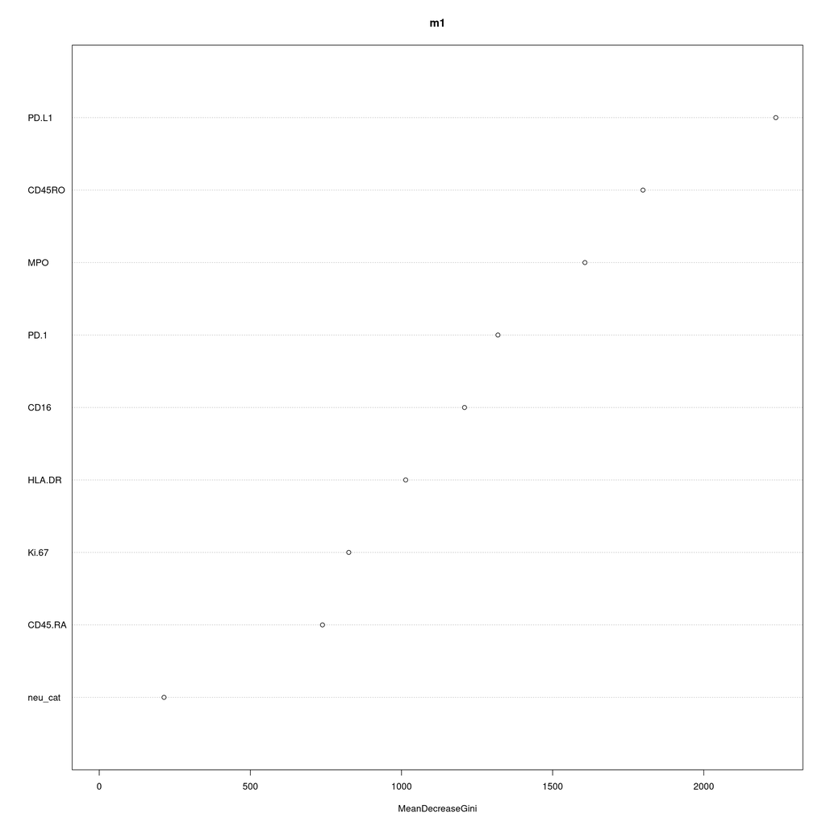

```r
varImpPlot(m1)
```

Difficulties:

- Couldn’t really include any metadata because too many repeats, which artificially inflate the prediction accuracy and importance of those variables. That’s a big deal breaker
- We subset to only neutrophils so we are basically classifying FOV with relapse/non-relapse predition on neutrophils. This is somewhat OK.

### Strategy 2

```r
fov_summary <- fov_summary %>%
  mutate(neu_near_prop = neutrophil_count_near/(neutrophil_count_far + neutrophil_count_near),
         neu_far_prop = neutrophil_count_far/(neutrophil_count_far + neutrophil_count_near))

set.seed(123)

unique_fov <- unique(fov_summary$fov)

train_fov <- sample(unique_fov, round(0.7 * length(unique_fov)))

test_fov <- setdiff(unique_fov, train_fov)

train <- fov_summary %>%
  filter(fov %in% train_fov) %>%
  mutate(Relapse = factor(Relapse))

test <- fov_summary %>%
  anti_join(train) %>%
  mutate(Relapse = factor(Relapse))
```

```r
formula <- as.formula(paste('Relapse ~ ', paste(colnames(fov_summary[c(3:18, 21)]), collapse = " + ")))

m2 <- randomForest(formula, data = train)

test$pred <- predict(m2, test)

cat("Accuracy:\n")
```

```
## Accuracy:
```

```r
sum(test$Relapse == test$pred) / nrow(test)
```

```
## [1] 0.8888889
```

```r
cat("Variable importance:\n")
```

```
## Variable importance:
```

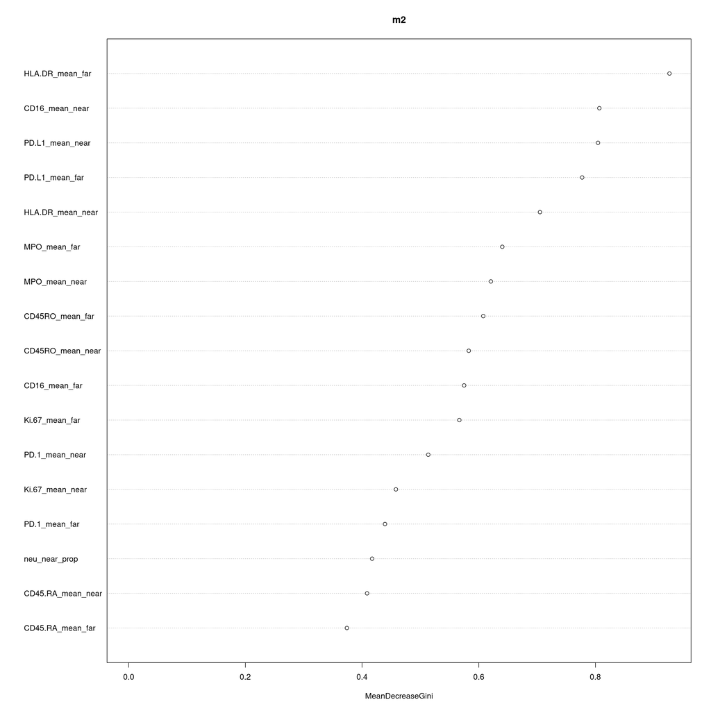

```r
varImpPlot(m2)
```

Difficulties:

- sample size too small while too many variables. Result very unreliable. Should abandon this approach.

### Strategy 3

#### FOV approach, sample by patient. Repeated 3-fold cross validation

There are several caveats that need to be addressed:

1. Since each patient can have multiple FOVs, it’s paramount to perform the training and testing split at patient level to prevent information leakage when fitting the model.
2. Since our response variable — relapse/non-relapse — is a patient level feature, our effective sample size is small with 8 relapse patients and 4 non-relapse patients. With the limited sample size, we use a repeated 3-fold cross validation to get relatively more robust results.
3. Due to the limited sample size, all model fitting results should be taken cautiously.

```r
pca_near <- pca_plot_near %>%
  mutate(bin = 'near')

pca_far <- pca_plot_far %>%
  mutate(bin = 'far')

pca_df <- pca_near %>%
  full_join(pca_far) %>%
  mutate(bin = factor(bin))
```

[interactive chart not shown]

```r
#####################################################
# 1. Setup Parameters
#####################################################

# Cross-validation parameters
k_folds <- 3         # Using fewer folds since you only have 12 patients
n_repeats <- 10      # Number of repetitions
n_trees <- 500       # Number of trees per forest

# Create data frame to store results
result_summary <- data.frame(
  fold = character(),
  repetition = numeric(),
  accuracy = numeric(),
  precision = numeric(),
  recall = numeric(),
  F1 = numeric(),
  var1 = character(),
  var2 = character(),
  var3 = character(),
  var4 = character(),
  var5 = character(),
  train_patients = character(),
  test_patients = character()
)

# Variable to store importance values across all folds
all_importance <- list()

all_models <- list()

#####################################################
# 2. Repeated K-fold Cross-Validation Function
#####################################################

run_cv <- function(pca_summary, formula, k_folds, n_repeats) {

  # Get unique patients by relapse status
  unique_relapse_patients <- unique(pca_summary$patient[pca_summary$relapse == 'Y'])
  unique_non_patients <- unique(pca_summary$patient[pca_summary$relapse == 'N'])

  # Create a data frame of patients with their relapse status
  patients_df <- data.frame(
    patient = c(unique_relapse_patients, unique_non_patients),
    relapse = c(rep('Y', length(unique_relapse_patients)),
                rep('N', length(unique_non_patients)))
  )

  # Create a list to store all fold information
  all_folds <- list()
  fold_counter <- 1

  # Generate repeated k-fold splits at PATIENT level
  for (rep in 1:n_repeats) {
    # Set a different seed for each repetition
    set.seed(123 + rep)

    # Create stratified folds - keeping relapse and non-relapse patients balanced
    folds <- createFolds(patients_df$relapse, k = k_folds, list = TRUE, returnTrain = FALSE)

    for (fold in 1:k_folds) {
      # Get test patient IDs for this fold
      test_patient_indices <- folds[[fold]]
      test_patients <- patients_df$patient[test_patient_indices]

      # Get train patient IDs (all patients not in test)
      train_patients <- setdiff(patients_df$patient, test_patients)

      # Store in the list
      all_folds[[fold_counter]] <- list(
        rep = rep,
        fold = fold,
        train_patients = train_patients,
        test_patients = test_patients
      )

      fold_counter <- fold_counter + 1
    }
  }

  # Initialize result data frame
  results <- data.frame()

  # Run models for all folds
  for (i in 1:length(all_folds)) {
    # Get patients for this fold
    train_patients <- all_folds[[i]]$train_patients
    test_patients <- all_folds[[i]]$test_patients
    rep_num <- all_folds[[i]]$rep
    fold_num <- all_folds[[i]]$fold

    # Get FOVs corresponding to these patients
    train_fov <- pca_summary$fov[pca_summary$patient %in% train_patients]
    test_fov <- pca_summary$fov[pca_summary$patient %in% test_patients]

    # Create training and testing datasets
    train <- pca_summary %>%
      filter(fov %in% train_fov) %>%
      mutate(relapse = factor(relapse))

    test <- pca_summary %>%
      filter(fov %in% test_fov) %>%
      mutate(relapse = factor(relapse))

    # Check if we have both classes in the training set
    if (length(unique(train$relapse)) < 2) {
      warning(paste("Fold", i, "has only one class in training set. Skipping."))
      next
    }

    # Train random forest model
    m <- randomForest(formula,
                      data = train,
                      ntree = n_trees)

    if (rep_num == 1) {
      all_models[[fold_num]] <- m
    }

    # Make predictions
    test$pred <- predict(m, test)

    # Calculate metrics
    # Add small epsilon to prevent division by zero in edge cases
    epsilon <- 1e-10

    accuracy <- sum(test$relapse == test$pred) / nrow(test)

    recall <- sum(test$relapse == 'Y' & test$pred == 'Y') /
      (sum(test$relapse == 'Y') + epsilon)

    precision <- sum(test$relapse == 'Y' & test$pred == 'Y') /
      (sum(test$pred == 'Y') + epsilon)

    F1 <- 2 * precision * recall / (precision + recall + epsilon)

    # Get variable importance
    var_imp <- varImp(m)
    var_imp$variable <- rownames(var_imp)

    # Store variable importance for later aggregation
    all_importance[[i]] <- var_imp

    # Get top 5 important variables
    top_vars <- var_imp %>%
      slice_max(order_by = Overall, n = 5)

    imp_vars <- top_vars$variable

    # If fewer than 5 variables, pad with NA
    if (length(imp_vars) < 5) {
      imp_vars <- c(imp_vars, rep(NA, 5 - length(imp_vars)))
    }

    # Store results
    result_summary <- rbind(result_summary, data.frame(
      fold = fold_num,
      repetition = rep_num,
      accuracy = accuracy,
      precision = precision,
      recall = recall,
      F1 = F1,
      var1 = imp_vars[1],
      var2 = imp_vars[2],
      var3 = imp_vars[3],
      var4 = imp_vars[4],
      var5 = imp_vars[5],
      train_patients = paste(train_patients, collapse = ', '),
      test_patients = paste(test_patients, collapse = ', ')
    ))
  }

  return(list(result_summary = result_summary, all_importance = all_importance, all_models = all_models))
}
```

```
## Average Performance Metrics Across All Folds:
```

```
## Accuracy: 0.4976419
```

```
## Precision: 0.5953285
```

```
## Recall: 0.7465212
```

```
## F1 Score: 0.6453153
```

```
## # A tibble: 10 × 8
##    variable mean_importance sd_importance min_importance max_importance lower_ci
##    <chr>              <dbl>         <dbl>          <dbl>          <dbl>    <dbl>
##  1 PC2_mea…           1.01          0.580          0.250          2.28     0.250
##  2 PC6_mea…           0.790         0.342          0.271          1.90     0.348
##  3 PC4_mea…           0.727         0.434          0.141          1.54     0.166
##  4 PC8_mea…           0.692         0.242          0.299          1.22     0.355
##  5 PC3_mea…           0.592         0.364          0.194          1.48     0.220
##  6 PC5_mea…           0.590         0.276          0.179          1.47     0.217
##  7 PC8_mea…           0.538         0.190          0.342          1.24     0.344
##  8 PC5_mea…           0.535         0.233          0.198          0.949    0.203
##  9 PC2_mea…           0.513         0.339          0.136          1.73     0.142
## 10 PC1_mea…           0.493         0.210          0.122          1.05     0.221
## # ℹ 2 more variables: upper_ci <dbl>, frequency <int>
```

```
## # A tibble: 15 × 2
##    variable      total_count
##    <chr>               <dbl>
##  1 PC2_mean_near          22
##  2 PC6_mean_near          19
##  3 PC8_mean_near          17
##  4 PC4_mean_near          14
##  5 PC5_mean_near          13
##  6 PC5_mean_far           10
##  7 PC3_mean_far            9
##  8 PC1_mean_near           8
##  9 PC8_mean_far            8
## 10 PC1_mean_far            7
## 11 PC7_mean_far            7
## 12 PC2_mean_far            6
## 13 PC3_mean_near           5
## 14 PC4_mean_far            4
## 15 PC7_mean_near           1
```

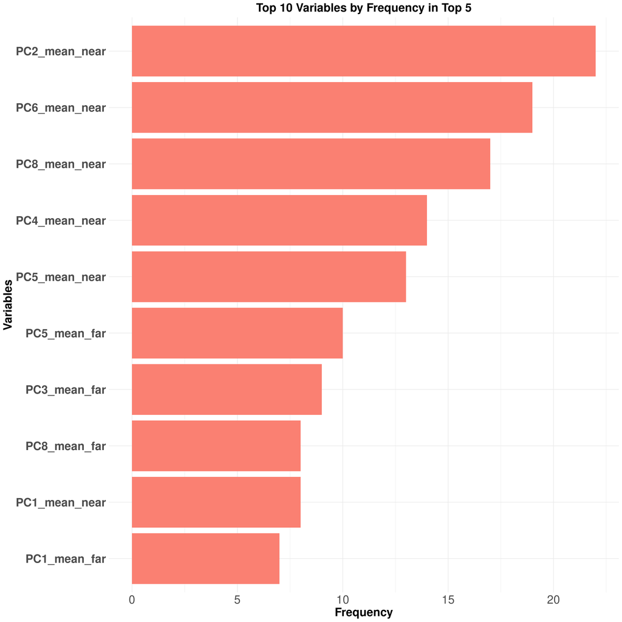

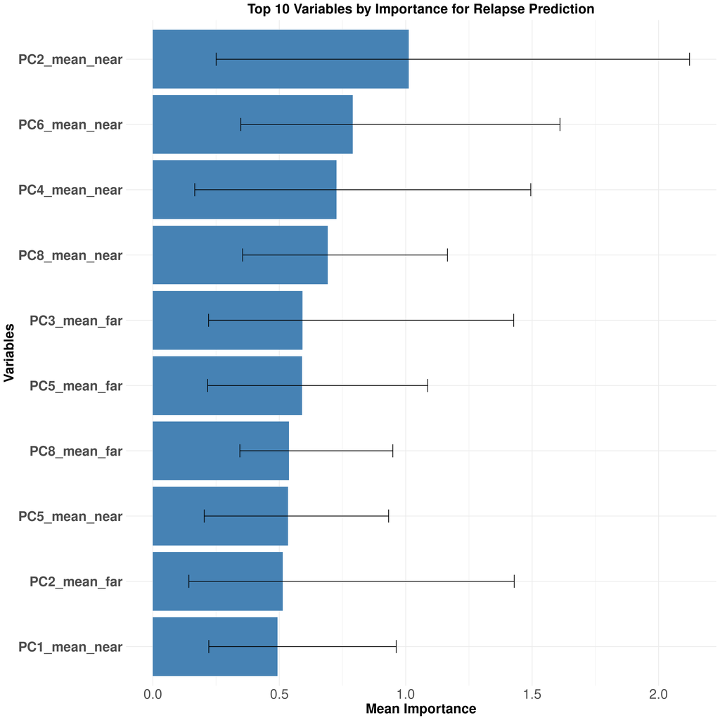

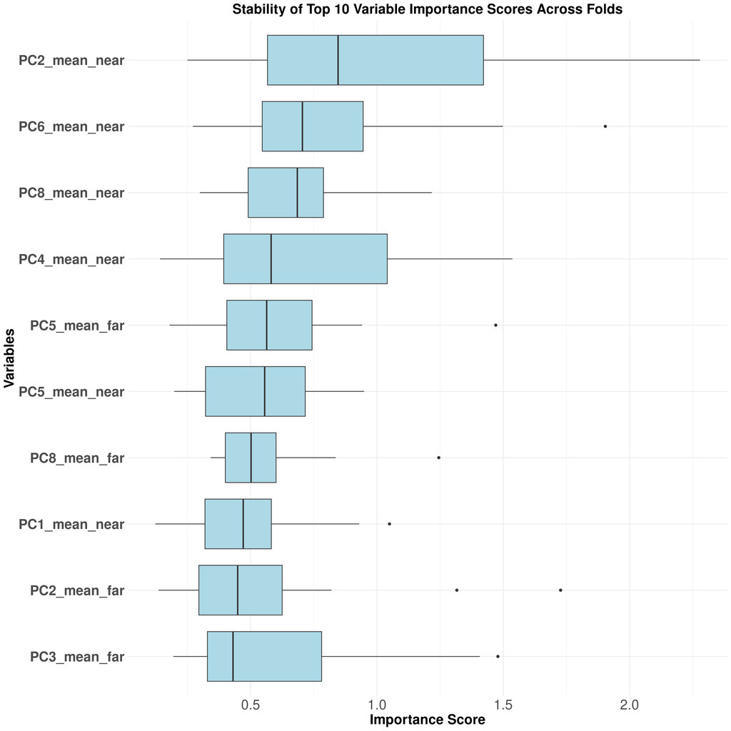

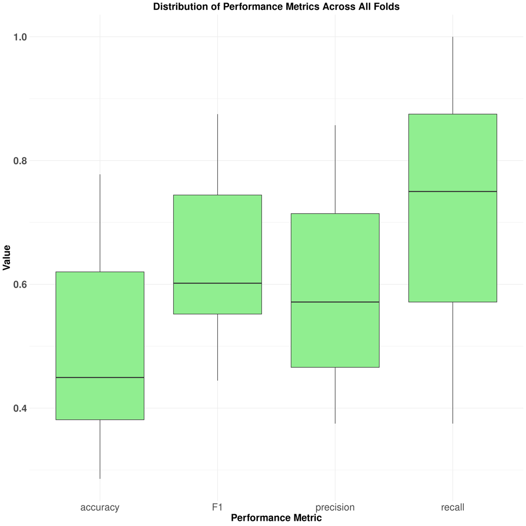

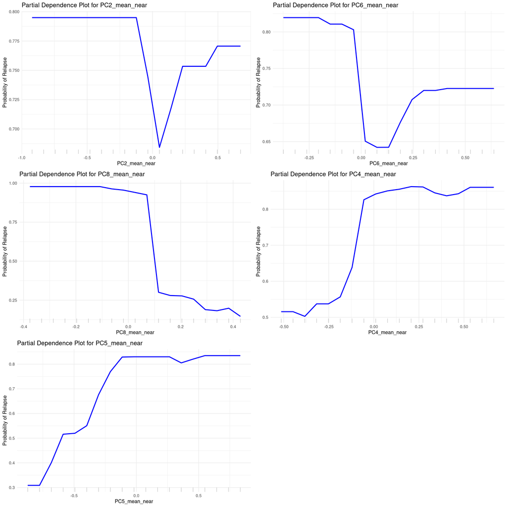

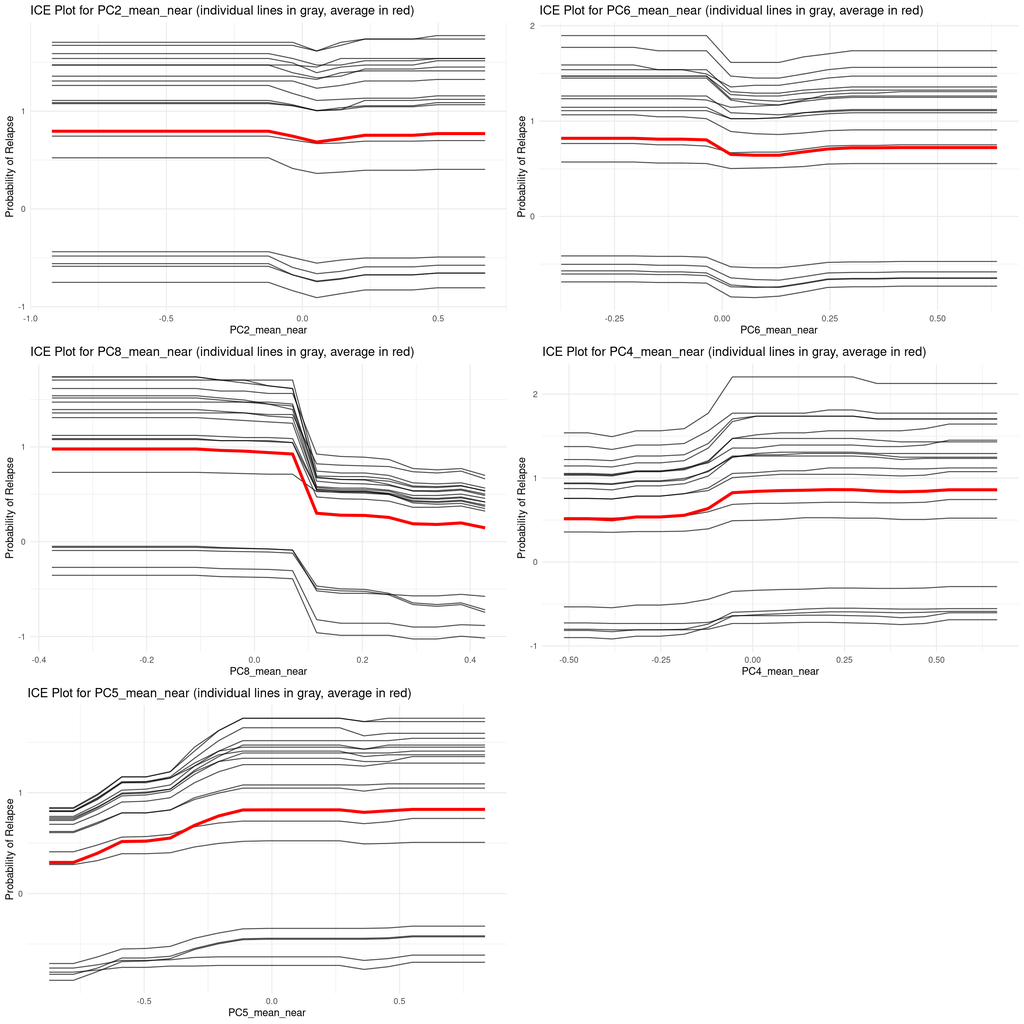

What is a **P**artial **D**ependency **P**lot (PDP)? In our case of a random forest model, replace the split criterion of a corresponding variable when it appears in a tree; run through all trees; calculate the corresponding prediction probability.

This indicates that higher values of `PC4_mean_near` are strongly correlated with increased probability of relapse.

What is a **I**ndividual **C**onditional **E**xpectation (ICE) plot? It’s basically a PDP on observation level. It shows how the relapse probability for a individual observation (an FOV in our case) changes when we change the value of a variable.

Now let’s examine the composition of each of the top 5 important principle components to see if there is any biological insight.

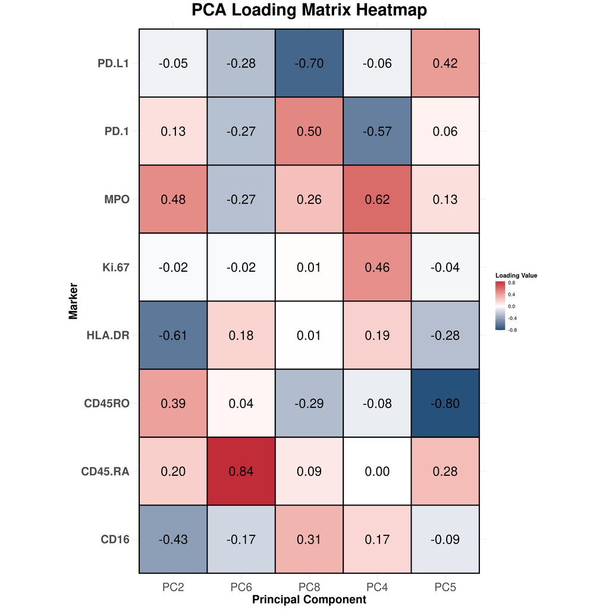